# Impact of homelessness on surgical outcomes - VAS

# Background

The following observational analysis has been designed to determine the impact of homelessness on surgical outcomes. To assess this impact, if any, we fit several linear models containing their housing status and other potentially confounding variables to determine whether there is an impact and quantify it.

The St Vincent’s Hospital Sydney Coding Office (SVHSCO) provided the data sets relating to these outcomes.

# Methods

Binary logistic regression and linear logistic regression were used to analyse associations between our complication factors as independent variables to each endpoint. Using the outputs from these models, we determine which variables have a significant effect on each outcome. We then remove the non-significant variables from the models to arrive at final models from which we can determine effect sizes for each complication factor.

## Enpoints

The primary efficacy endpoint is:

- Surgical complication as `complication`: logical variable indicating whether the patient had a complication associated with their operation.

and the secondary endpoints include:

- Patient Mortality as `mortality`: a logical variable indicating whether the patient died during their hospital admission.
- Length of Stay as`los` a measurement of in days of how long each patient stayed in hospital.
- ICU Admission as `icu_admission`: a logical variable indicating whether the patient was admitted to ICU.
- ICU Hours as `icu_hrs`: a measurement in hours of how long the patient spent in ICU.
- Discharge against medical advice as `daor`: a logical variable indicating whether patients discharged themselves at their own risk.

## Complication factors

The variable of interest was:

- Housing Status as `status`: the patient’s housing status undergoing surgery.

Other potentially confounding variables considered as part of the analysis were:

- Patient Age as `age`: a measurement of the patient’s age in decades at the time of admission.
- Patient Sex as `sex`: sex of the patient.
- Drug and Alcohol Disorder as `da_disorder`: whether the patient had a drug and alcohol disorder associated with their admission.
- Mental Illness as `mental_illness`: whether the patient had a drug and a mental illness associated with their admission.

The datasets were exported by SVHSCO to a set of google sheets which was then ingested by this analysis document.

# Environment set-up

First we set up our environment by loading the following packages.

```r
# load libraries
library(googlesheets4)
library(googledrive)
library(tidyverse)
library(reshape2)
library(janitor)
library(skimr)
library(scales)
library(ggplot2)
library(ggpubr)
library(chisq.posthoc.test)
library(jtools)
```

# Data load, clean and feature engineering

The data is contained as a google sheet. The following routine fetches, cleans and generates features from these datasets to create an analysis data frame called `homeless_data`.

The cleaning process involves the following processes:

- All non-surgical patient admissions were filtered out of the data set.
- `NA` values for `assoc_diseases` were encoded as `NONE`
- `NA` values for `icu_hrs` were encoded as 0.

The features we generate are:

- `complication`: a logical variable as defined by the inclusion of `assoc_diseases` beginning with `T8`.
- `icu_admission`: logical variable defined by the `icu_hrs` variable greater than 0.
- `da_disorder`: a logical variable defined by the inclusion of `assoc_diseases` beginning with `F1`, except `F17`.
- `mental_illness`: a logical variable defined by the inclusion of `assoc_diseases` beginning with `F2`, `F3` or `F4`.
- `daor`: as logical variable as defined by a `discharge_status` equal to `Discharge at Own Risk` meaning that the patient discharged themselves against medical advice.

```r
# load data by looping through the sheets
sheets <- vector(mode = "list", length = 2)

for (s in 1:2){

  sheets[[s]] <- drive_get("Homeless Data") %>%
    read_sheet(sheet = s) %>%
    clean_names() %>%
    select(sex, age, assoc_diseases, spec, los, icu_hrs, discharge_status) %>%
    mutate(status = c("domiciled", "homeless")[s])

}

# bind the sheets together and clean
homeless_data <- bind_rows(sheets) %>%
  filter(spec %in% c("OT1", "OT2", "CRS", "NS", "HNO", "PLS", "CTS", "VAS", "SOC", "ENT", "URO", "GIT")) %>%
  mutate_at(vars(c("sex", "spec", "discharge_status", "status")), as.factor) %>%
  replace_na(list(assoc_diseases = "NONE",
                  icu_hrs = 0))

# feature engineering
homeless_data <- homeless_data %>%
  mutate(complication = ifelse(str_detect(assoc_diseases, "T8"), T, F),
         age = age/10, # want to represent age in decades in analysis
         mortality = ifelse(str_detect(as.character(discharge_status), "DEATH"), T, F),
         icu_admission = ifelse(icu_hrs > 0, T, F),
         da_disorder = str_detect(assoc_diseases, paste(paste0("F", c(10:16, 18:19)), collapse = "|")),
         mental_illness = case_when(
           str_detect(assoc_diseases, "F2") ~ T,
           str_detect(assoc_diseases, "F3") ~ T,
           str_detect(assoc_diseases, "F4") ~ T,
           TRUE ~ F
           ),
         daor = ifelse(discharge_status == "Discharge at Own Risk", T, F))

# add in descriptions for spec
homeless_data <- homeless_data %>%
  mutate(spec_desc = case_when(
    spec %in% c('GIT', 'CRS', 'HNO', 'SOC') ~ 'GS',
    spec %in% c('OT1', 'OT2')               ~ 'ORT',
    TRUE                                    ~ as.character(spec)
  ) %>% as.factor())

# only focus on vascular patients
homeless_data <- homeless_data %>%
  filter(spec == "VAS")

# skim set by status group
homeless_data %>%
  group_by(status) %>%
  skim()
```

Data summary

| Name | Piped data |
| --- | --- |
| Number of rows | 285 |
| Number of columns | 15 |
| _______________________ |  |
| Column type frequency: |  |
| character | 1 |
| factor | 4 |
| logical | 6 |
| numeric | 3 |
| ________________________ |  |
| Group variables | status |

**Variable type: character**

| skim_variable | status | n_missing | complete_rate | min | max | empty | n_unique | whitespace |
| --- | --- | --- | --- | --- | --- | --- | --- | --- |
| assoc_diseases | domiciled | 0 | 1 | 4 | 254 | 0 | 274 | 0 |
| assoc_diseases | homeless | 0 | 1 | 62 | 253 | 0 | 11 | 0 |

**Variable type: factor**

| skim_variable | status | n_missing | complete_rate | ordered | n_unique | top_counts |
| --- | --- | --- | --- | --- | --- | --- |
| sex | domiciled | 0 | 1 | FALSE | 2 | M: 208, F: 66 |
| sex | homeless | 0 | 1 | FALSE | 1 | M: 11, F: 0 |
| spec | domiciled | 0 | 1 | FALSE | 1 | VAS: 274, CRS: 0, CTS: 0, ENT: 0 |
| spec | homeless | 0 | 1 | FALSE | 1 | VAS: 11, CRS: 0, CTS: 0, ENT: 0 |
| discharge_status | domiciled | 0 | 1 | FALSE | 7 | Dis: 174, Typ: 46, Tra: 32, Tra: 8 |
| discharge_status | homeless | 0 | 1 | FALSE | 4 | Dis: 6, Typ: 3, Dis: 1, Tra: 1 |
| spec_desc | domiciled | 0 | 1 | FALSE | 1 | VAS: 274, CTS: 0, ENT: 0, GS: 0 |
| spec_desc | homeless | 0 | 1 | FALSE | 1 | VAS: 11, CTS: 0, ENT: 0, GS: 0 |

**Variable type: logical**

| skim_variable | status | n_missing | complete_rate | mean | count |
| --- | --- | --- | --- | --- | --- |
| complication | domiciled | 0 | 1 | 0.24 | FAL: 208, TRU: 66 |
| complication | homeless | 0 | 1 | 0.36 | FAL: 7, TRU: 4 |
| mortality | domiciled | 0 | 1 | 0.02 | FAL: 269, TRU: 5 |
| mortality | homeless | 0 | 1 | 0.00 | FAL: 11 |
| icu_admission | domiciled | 0 | 1 | 0.29 | FAL: 195, TRU: 79 |
| icu_admission | homeless | 0 | 1 | 0.55 | TRU: 6, FAL: 5 |
| da_disorder | domiciled | 0 | 1 | 0.11 | FAL: 243, TRU: 31 |
| da_disorder | homeless | 0 | 1 | 0.55 | TRU: 6, FAL: 5 |
| mental_illness | domiciled | 0 | 1 | 0.01 | FAL: 270, TRU: 4 |
| mental_illness | homeless | 0 | 1 | 0.27 | FAL: 8, TRU: 3 |
| daor | domiciled | 0 | 1 | 0.03 | FAL: 267, TRU: 7 |
| daor | homeless | 0 | 1 | 0.09 | FAL: 10, TRU: 1 |

**Variable type: numeric**

| skim_variable | status | n_missing | complete_rate | mean | sd | p0 | p25 | p50 | p75 | p100 | hist |
| --- | --- | --- | --- | --- | --- | --- | --- | --- | --- | --- | --- |
| age | domiciled | 0 | 1 | 7.02 | 1.61 | 2 | 6.10 | 7.3 | 8.2 | 10.3 | ▁▂▆▇▂ |
| age | homeless | 0 | 1 | 6.13 | 0.62 | 5 | 5.85 | 6.0 | 6.4 | 7.3 | ▂▇▆▂▃ |
| los | domiciled | 0 | 1 | 16.07 | 15.89 | 1 | 6.25 | 11.5 | 21.0 | 101.0 | ▇▂▁▁▁ |
| los | homeless | 0 | 1 | 22.73 | 16.06 | 5 | 13.00 | 17.0 | 26.5 | 54.0 | ▇▃▆▁▃ |
| icu_hrs | domiciled | 0 | 1 | 16.19 | 37.51 | 0 | 0.00 | 0.0 | 18.5 | 253.0 | ▇▁▁▁▁ |
| icu_hrs | homeless | 0 | 1 | 25.09 | 33.09 | 0 | 0.00 | 11.0 | 44.0 | 80.0 | ▇▂▁▁▃ |

# Results

## Initial contingency table analysis

First, we perform a one-sided Fisher’s Exact Test to determine whether an association existed between homelessness and greater surgical complication risk.

```r
comp_table <- homeless_data %>%
  with(table(complication, status)) %>%
  .[order(-as.logical(row.names(.))), ]

comp_table
```

```
##             status
## complication domiciled homeless
##        TRUE         66        4
##        FALSE       208        7
```

```r
comp_table %>%
  fisher.test(., alternative = 'less')
```

```
##
##  Fisher's Exact Test for Count Data
##
## data:  .
## p-value = 0.272
## alternative hypothesis: true odds ratio is less than 1
## 95 percent confidence interval:
##  0.000000 2.096004
## sample estimates:
## odds ratio
##   0.556599
```

## Prevalence of confounders amongst population groups

### Continuous confounders

```r
# display summary statistics of age across both populations
homeless_data %>%
  group_by(status) %>%
  summarise(ave_age = mean(age),
            median_age = median(age),
            sd_age = sd(age),
            q0 = quantile(age, 0),
            q25 = quantile(age, 0.25),
            q75 = quantile(age, 0.75),
            q100 = quantile(age, 1))
```

```
## # A tibble: 2 × 8
##   status    ave_age median_age sd_age    q0   q25   q75  q100
##   <fct>       <dbl>      <dbl>  <dbl> <dbl> <dbl> <dbl> <dbl>
## 1 domiciled    7.02        7.3  1.61      2  6.1    8.2  10.3
## 2 homeless     6.13        6    0.618     5  5.85   6.4   7.3
```

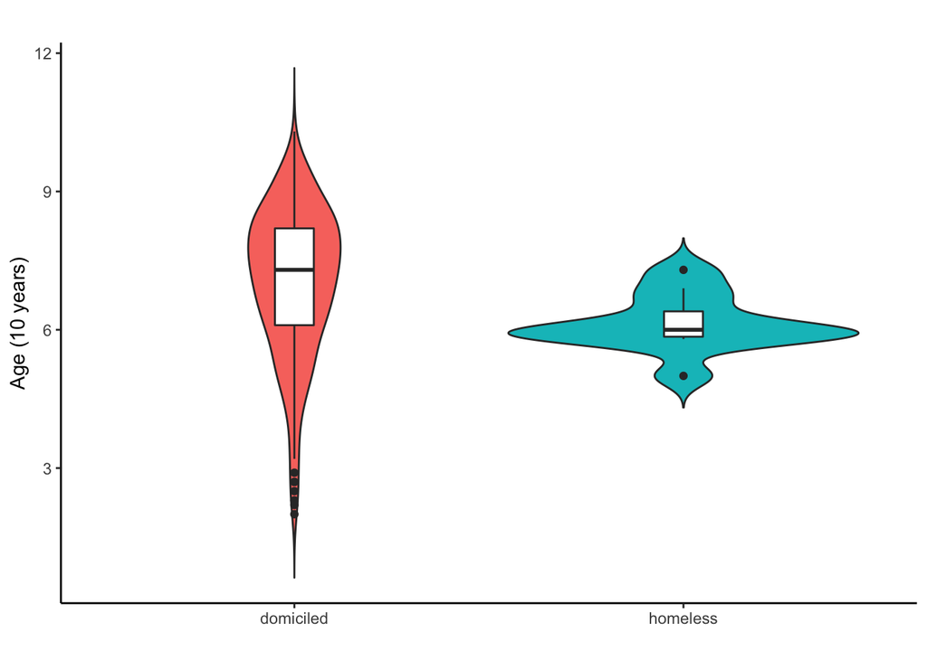

```r
# graph the distributions
p1 <- homeless_data %>%
  ggplot(aes(x = status, y = age, fill = status)) +
    geom_violin(trim = FALSE) +
    geom_boxplot(width = 0.1, fill = "white") +
    labs(title = "", x = "", y = "Age (10 years)") +
    theme_classic() +
    theme(legend.position="none")

p1
```

```r
# conduct test to find whether medians are different
kruskal.test(age ~ status, data = homeless_data)
```

```
##
##  Kruskal-Wallis rank sum test
##
## data:  age by status
## Kruskal-Wallis chi-squared = 6.8449, df = 1, p-value = 0.00889
```

### Categorical confounders

```r
# find the contingency tables of confounders amongst both populations
con_tab <- homeless_data %>%
  select(status, sex, da_disorder,  mental_illness) %>%
  lapply(., function(x) table(.$status, x)) %>% .[-1]

con_tab
```

```
## $sex
##            x
##               F   M
##   domiciled  66 208
##   homeless    0  11
##
## $da_disorder
##            x
##             FALSE TRUE
##   domiciled   243   31
##   homeless      5    6
##
## $mental_illness
##            x
##             FALSE TRUE
##   domiciled   270    4
##   homeless      8    3
```

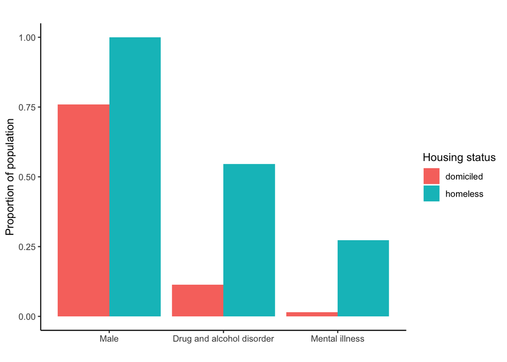

```r
p2 <- homeless_data %>%
  mutate(sex = ifelse(sex == 'M', T, F)) %>%
  group_by(status) %>%
  summarise_at(vars(sex, da_disorder,  mental_illness), function(x) mean(x)) %>%
  melt(variable.name = "confounder", value.name = "proportion") %>%
  ggplot(aes(x = confounder, y = proportion, fill = status)) +
    geom_bar(stat = "identity", position = position_dodge()) +
    labs(title = '',
         fill = 'Housing status') +
    ylab('Proportion of population') +
    xlab('') +
    scale_x_discrete(labels = c("sex" = "Male", "da_disorder" = "Drug and alcohol disorder", "mental_illness" = "Mental illness")) +
    theme_classic()

p2
```

```r
# show these contingency tables as prop tables
con_tab %>% lapply(., function(x) prop.table(x, margin = 1))
```

```
## $sex
##            x
##                     F         M
##   domiciled 0.2408759 0.7591241
##   homeless  0.0000000 1.0000000
##
## $da_disorder
##            x
##                 FALSE      TRUE
##   domiciled 0.8868613 0.1131387
##   homeless  0.4545455 0.5454545
##
## $mental_illness
##            x
##                  FALSE       TRUE
##   domiciled 0.98540146 0.01459854
##   homeless  0.72727273 0.27272727
```

```r
# determine whether the odds of their occurrence is different using fisher test
con_tab %>% lapply(., fisher.test)
```

```
## $sex
##
##  Fisher's Exact Test for Count Data
##
## data:  X[[i]]
## p-value = 0.07352
## alternative hypothesis: true odds ratio is not equal to 1
## 95 percent confidence interval:
##  0.7704071       Inf
## sample estimates:
## odds ratio
##        Inf
##
##
## $da_disorder
##
##  Fisher's Exact Test for Count Data
##
## data:  X[[i]]
## p-value = 0.0009217
## alternative hypothesis: true odds ratio is not equal to 1
## 95 percent confidence interval:
##   2.215466 40.902794
## sample estimates:
## odds ratio
##   9.271374
##
##
## $mental_illness
##
##  Fisher's Exact Test for Count Data
##
## data:  X[[i]]
## p-value = 0.001388
## alternative hypothesis: true odds ratio is not equal to 1
## 95 percent confidence interval:
##    3.060948 172.633326
## sample estimates:
## odds ratio
##   24.26356
```

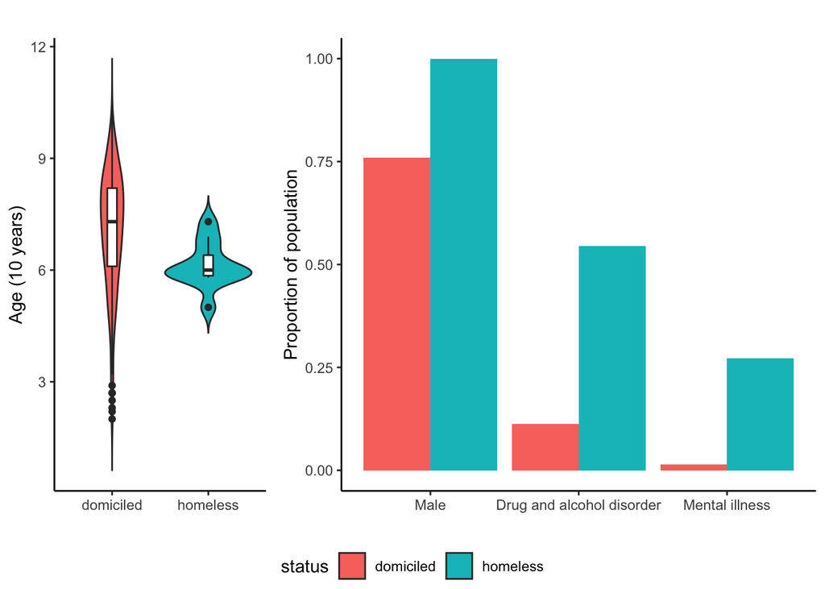

```r
# combine the graphs together
ggarrange(p1, p2,
          widths = c(0.5, 1),
          common.legend = T,
          legend = "bottom")
```

## Linear Regression analysis

Here we fit sets of linear models to our outcomes to determine how the variables we are investigating relate to our outcomes of interest and use the coefficients of the models to determine the potential risk they carry.

### Surgical complication

To determine the effects on complication risk during surgery we fit a logistic regression model to our dataset as so:

```r
comp_glm <- glm(complication ~ status + age + sex + da_disorder + mental_illness,
                family = binomial(),
                data = homeless_data)

comp_glm_summary <- comp_glm %>% summary
comp_glm_summary
```

```
##
## Call:
## glm(formula = complication ~ status + age + sex + da_disorder +
##     mental_illness, family = binomial(), data = homeless_data)
##
## Deviance Residuals:
##     Min       1Q   Median       3Q      Max
## -1.1322  -0.7173  -0.6781  -0.6605   1.8010
##
## Coefficients:
##                    Estimate Std. Error z value Pr(>|z|)
## (Intercept)        -0.77008    0.71258  -1.081   0.2798
## statushomeless      0.44232    0.71459   0.619   0.5359
## age                -0.02439    0.09017  -0.270   0.7868
## sexM               -0.40249    0.32395  -1.242   0.2141
## da_disorderTRUE     0.74480    0.40121   1.856   0.0634 .
## mental_illnessTRUE -0.36331    0.93565  -0.388   0.6978
## ---
## Signif. codes:  0 '***' 0.001 '**' 0.01 '*' 0.05 '.' 0.1 ' ' 1
##
## (Dispersion parameter for binomial family taken to be 1)
##
##     Null deviance: 317.76  on 284  degrees of freedom
## Residual deviance: 312.21  on 279  degrees of freedom
## AIC: 324.21
##
## Number of Fisher Scoring iterations: 4
```

We observe that the variable `status` (P = 0.5359208) didn’t contribute to the model. As such we eliminate the term from the modelling to reach our final model.

```r
comp_glm_final <- glm(complication ~ age + sex + da_disorder + mental_illness,
                      family = binomial(),
                      data = homeless_data)

# get interesting stuff into a df
comp_glm_final %>%
  summ(confint = TRUE, digits = 3)
```

```
## MODEL INFO:
## Observations: 285
## Dependent Variable: complication
## Type: Generalized linear model
##   Family: binomial
##   Link function: logit
##
## MODEL FIT:
## χ²(4) = 5.175, p = 0.270
## Pseudo-R² (Cragg-Uhler) = 0.027
## Pseudo-R² (McFadden) = 0.016
## AIC = 322.580, BIC = 340.843
##
## Standard errors: MLE
## -------------------------------------------------------------------
##                              Est.     2.5%   97.5%   z val.       p
## ------------------------ -------- -------- ------- -------- -------
## (Intercept)                -0.761   -2.153   0.631   -1.071   0.284
## age                        -0.027   -0.203   0.149   -0.298   0.766
## sexM                       -0.381   -1.012   0.250   -1.185   0.236
## da_disorderTRUE             0.785    0.011   1.558    1.989   0.047
## mental_illnessTRUE         -0.182   -1.895   1.530   -0.209   0.835
## -------------------------------------------------------------------
```

```r
# transform the coefficients into risk factors
comp_glm_final %>%
  with(cbind(exp(coefficients(.)), exp(confint(.))))
```

```
##                                  2.5 %   97.5 %
## (Intercept)        0.4672025 0.1112422 1.828171
## age                0.9736331 0.8182111 1.165309
## sexM               0.6828966 0.3663086 1.301354
## da_disorderTRUE    2.1918145 0.9958560 4.726238
## mental_illnessTRUE 0.8334052 0.1131100 4.162801
```

```r
# transform the coefficients into risk factors
thing <- comp_glm_final %>%
  with(cbind(exp(coefficients(.)), exp(confint(.)))) %>% as.data.frame() %>%
  mutate(variable = rownames(.)) %>%
  rename("effect_size" = "V1") %>%
  filter(variable != "(Intercept)")

thing
```

```
##                    effect_size     2.5 %   97.5 %           variable
## age                  0.9736331 0.8182111 1.165309                age
## sexM                 0.6828966 0.3663086 1.301354               sexM
## da_disorderTRUE      2.1918145 0.9958560 4.726238    da_disorderTRUE
## mental_illnessTRUE   0.8334052 0.1131100 4.162801 mental_illnessTRUE
```

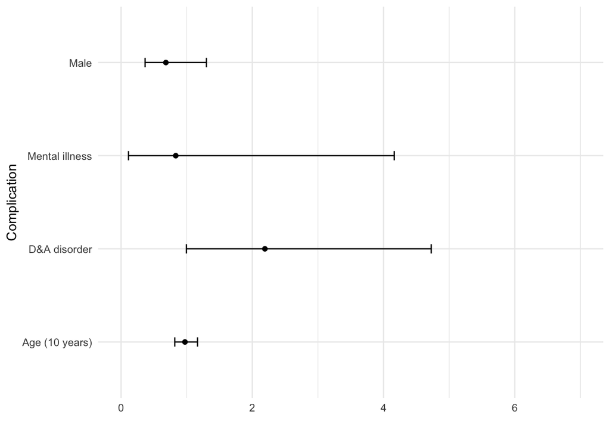

```r
risk_plot1 <- ggplot(thing, aes(x = variable, y = effect_size)) +
  geom_point() +
  geom_errorbar(aes(ymin = `2.5 %`, ymax = `97.5 %`), width = 0.1) +
  xlab('Complication') +
  ylab('') +
  ylim(0,7) +
  #scale_y_continuous(breaks= 0:7) +
  scale_x_discrete(labels = c("statushomeless" = "Homeless", "age" = "Age (10 years)", "sexM" = "Male", "da_disorderTRUE" = "D&A disorder", "mental_illnessTRUE" = "Mental illness")) +
  coord_flip() +
  theme_minimal()

risk_plot1
```

### Mortality

To determine the effects on mortality risk during surgery we fit a logistic regression model to our dataset as so:

```r
mort_glm <- glm(mortality ~ status + age + sex + da_disorder + mental_illness,
                family = binomial(),
                data = homeless_data)

mort_glm_summary <- mort_glm %>% summary
mort_glm_summary
```

```
##
## Call:
## glm(formula = mortality ~ status + age + sex + da_disorder +
##     mental_illness, family = binomial(), data = homeless_data)
##
## Deviance Residuals:
##     Min       1Q   Median       3Q      Max
## -0.2133  -0.2123  -0.2115  -0.1832   2.8586
##
## Coefficients:
##                      Estimate Std. Error z value Pr(>|z|)
## (Intercept)          -4.11222    2.32525  -1.769    0.077 .
## statushomeless      -15.73306 4703.18231  -0.003    0.997
## age                   0.00472    0.28492   0.017    0.987
## sexM                  0.29449    1.13022   0.261    0.794
## da_disorderTRUE     -16.45613 2805.42521  -0.006    0.995
## mental_illnessTRUE  -15.43898 5760.07007  -0.003    0.998
## ---
## Signif. codes:  0 '***' 0.001 '**' 0.01 '*' 0.05 '.' 0.1 ' ' 1
##
## (Dispersion parameter for binomial family taken to be 1)
##
##     Null deviance: 50.342  on 284  degrees of freedom
## Residual deviance: 48.535  on 279  degrees of freedom
## AIC: 60.535
##
## Number of Fisher Scoring iterations: 19
```

We observe that the variables `status` (P = 0.9973309), `da_disorder` (P = 0.9953198) and `mental_illness` (P = 0.9978614) don’t contribute to the model. As such we eliminate these terms from the modelling to reach our final model.

```r
mort_glm_final <- glm(mortality ~ age + sex,
                      family = binomial(),
                      data = homeless_data)

# get interesting stuff into a df
mort_glm_final %>%
  summ(confint = TRUE, digits = 3)
```

```
## MODEL INFO:
## Observations: 285
## Dependent Variable: mortality
## Type: Generalized linear model
##   Family: binomial
##   Link function: logit
##
## MODEL FIT:
## χ²(2) = 0.098, p = 0.952
## Pseudo-R² (Cragg-Uhler) = 0.002
## Pseudo-R² (McFadden) = 0.002
## AIC = 56.244, BIC = 67.202
##
## Standard errors: MLE
## ------------------------------------------------------------
##                       Est.     2.5%   97.5%   z val.       p
## ----------------- -------- -------- ------- -------- -------
## (Intercept)         -4.740   -9.510   0.030   -1.947   0.051
## age                  0.077   -0.506   0.660    0.258   0.796
## sexM                 0.217   -2.002   2.436    0.192   0.848
## ------------------------------------------------------------
```

```r
# transform the coefficients into risk factors
thing <- mort_glm_final %>%
  with(cbind(exp(coefficients(.)), exp(confint(.)))) %>% as.data.frame() %>%
  mutate(variable = rownames(.)) %>%
  rename("effect_size" = "V1") %>%
  filter(variable != "(Intercept)")

thing
```

```
##      effect_size     2.5 %    97.5 % variable
## age     1.079954 0.6337066  2.073519      age
## sexM    1.242374 0.1778584 24.671230     sexM
```

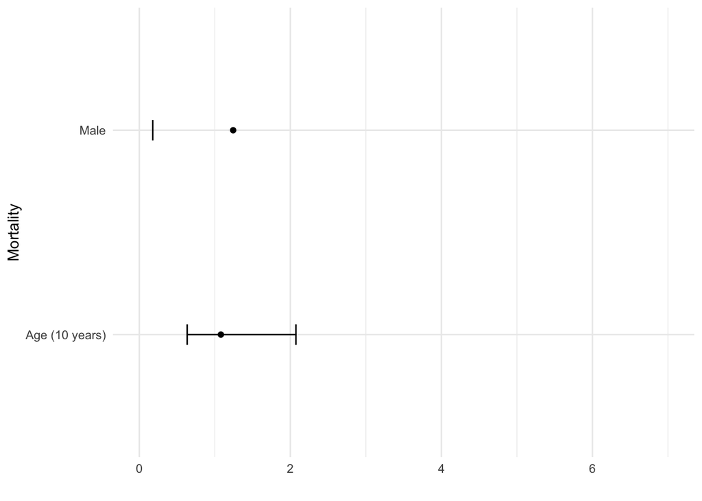

```r
risk_plot2 <- ggplot(thing, aes(x = variable, y = effect_size)) +
  geom_point() +
  geom_errorbar(aes(ymin = `2.5 %`, ymax = `97.5 %`), width = 0.1) +
  xlab('Mortality') +
  ylab('') +
  ylim(0,7) +
  #scale_y_continuous(breaks= 0:7) +
  scale_x_discrete(labels = c("statushomeless" = "Homeless", "age" = "Age (10 years)", "sexM" = "Male", "da_disorderTRUE" = "D&A disorder", "mental_illnessTRUE" = "Mental illness")) +
  coord_flip() +
  theme_minimal()

risk_plot2
```

### Length of Stay

To determine the effects on a patient’s length of stay, we fit linear models to our dataset. Firstly, we need to make a log transform to our outcome variable to fit the model correctly.

```r
# new log transformed outcome variable
homeless_data <- homeless_data %>%
  mutate(los_trans = log(los))

los_lm <- lm(los_trans ~ status + age + sex + da_disorder + mental_illness,
             data = homeless_data)

los_lm_summary <- los_lm %>% summary
los_lm_summary
```

```
##
## Call:
## lm(formula = los_trans ~ status + age + sex + da_disorder + mental_illness,
##     data = homeless_data)
##
## Residuals:
##      Min       1Q   Median       3Q      Max
## -2.65093 -0.47540  0.07575  0.63787  2.05833
##
## Coefficients:
##                    Estimate Std. Error t value Pr(>|t|)
## (Intercept)         1.18943    0.29016   4.099 5.44e-05 ***
## statushomeless      0.54281    0.31463   1.725  0.08559 .
## age                 0.16060    0.03627   4.428 1.37e-05 ***
## sexM               -0.01834    0.13461  -0.136  0.89174
## da_disorderTRUE     0.52773    0.17765   2.971  0.00323 **
## mental_illnessTRUE -0.37467    0.38662  -0.969  0.33334
## ---
## Signif. codes:  0 '***' 0.001 '**' 0.01 '*' 0.05 '.' 0.1 ' ' 1
##
## Residual standard error: 0.9445 on 279 degrees of freedom
## Multiple R-squared:  0.09174,    Adjusted R-squared:  0.07547
## F-statistic: 5.636 on 5 and 279 DF,  p-value: 5.729e-05
```

We observe that the variable `sex` (P = 0.891739) didn’t contribute to the model. As such we eliminate the terms from the modelling to reach our final model.

```r
los_lm_final <- lm(los_trans ~ status + age + da_disorder + mental_illness,
                   data = homeless_data)

# get interesting stuff into a df
los_lm_final %>%
  summ(confint = TRUE, digits = 3)
```

```
## MODEL INFO:
## Observations: 285
## Dependent Variable: los_trans
## Type: OLS linear regression
##
## MODEL FIT:
## F(4,280) = 7.066, p = 0.000
## R² = 0.092
## Adj. R² = 0.079
##
## Standard errors: OLS
## -------------------------------------------------------------------
##                              Est.     2.5%   97.5%   t val.       p
## ------------------------ -------- -------- ------- -------- -------
## (Intercept)                 1.173    0.652   1.695    4.432   0.000
## statushomeless              0.539   -0.077   1.154    1.723   0.086
## age                         0.161    0.090   0.232    4.454   0.000
## da_disorderTRUE             0.526    0.178   0.874    2.975   0.003
## mental_illnessTRUE         -0.371   -1.128   0.387   -0.963   0.336
## -------------------------------------------------------------------
```

```r
# transform the coefficients into risk factors
thing <- los_lm_final %>%
  with(cbind(exp(coefficients(.)), exp(confint(.)))) %>% as.data.frame() %>%
  mutate(variable = rownames(.)) %>%
  rename("effect_size" = "V1") %>%
  filter(variable != "(Intercept)")

thing
```

```
##                    effect_size     2.5 %   97.5 %           variable
## statushomeless       1.7135302 0.9262152 3.170090     statushomeless
## age                  1.1746010 1.0939679 1.261177                age
## da_disorderTRUE      1.6916334 1.1946330 2.395400    da_disorderTRUE
## mental_illnessTRUE   0.6902042 0.3235498 1.472360 mental_illnessTRUE
```

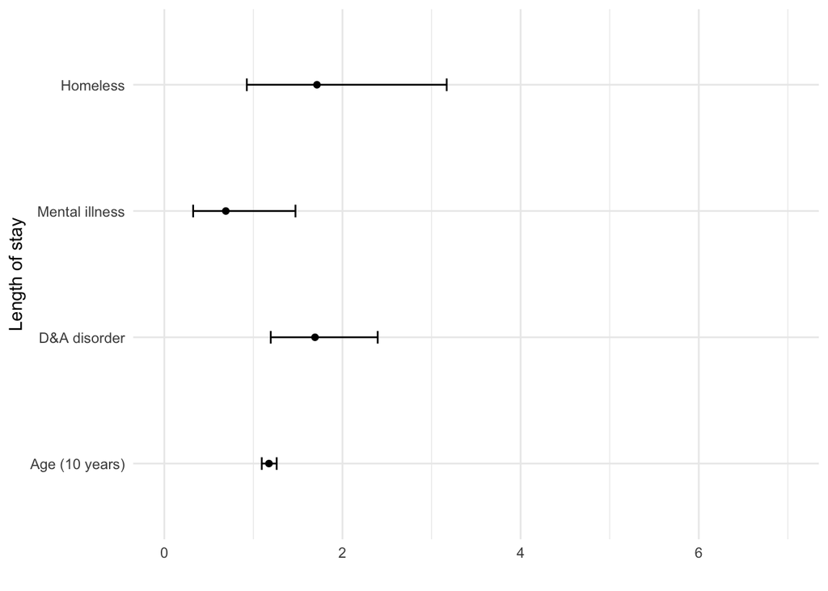

```r
risk_plot3 <- ggplot(thing, aes(x = variable, y = effect_size)) +
  geom_point() +
  geom_errorbar(aes(ymin = `2.5 %`, ymax = `97.5 %`), width = 0.1) +
  xlab('Length of stay') +
  ylab('') +
  ylim(0,7) +
  #scale_y_continuous(breaks= 0:7) +
  scale_x_discrete(labels = c("statushomeless" = "Homeless", "age" = "Age (10 years)", "sexM" = "Male", "da_disorderTRUE" = "D&A disorder", "mental_illnessTRUE" = "Mental illness")) +
  coord_flip() +
  theme_minimal()

risk_plot3
```

### ICU Admission

To determine the effects on ICU admission risk during surgery, we fit a logistic regression model to our dataset as so:

```r
icu_glm <- glm(icu_admission ~ status + age + sex + da_disorder + mental_illness,
               family = binomial(),
               data = homeless_data)

icu_glm_summary <- icu_glm %>% summary
icu_glm_summary
```

```
##
## Call:
## glm(formula = icu_admission ~ status + age + sex + da_disorder +
##     mental_illness, family = binomial(), data = homeless_data)
##
## Deviance Residuals:
##     Min       1Q   Median       3Q      Max
## -1.3753  -0.8806  -0.7469   1.4289   1.9127
##
## Coefficients:
##                    Estimate Std. Error z value Pr(>|z|)
## (Intercept)        -2.37624    0.74381  -3.195   0.0014 **
## statushomeless      1.16295    0.69310   1.678   0.0934 .
## age                 0.14442    0.09013   1.602   0.1091
## sexM                0.54571    0.34058   1.602   0.1091
## da_disorderTRUE     0.25516    0.41072   0.621   0.5344
## mental_illnessTRUE -0.63296    1.00383  -0.631   0.5283
## ---
## Signif. codes:  0 '***' 0.001 '**' 0.01 '*' 0.05 '.' 0.1 ' ' 1
##
## (Dispersion parameter for binomial family taken to be 1)
##
##     Null deviance: 347.34  on 284  degrees of freedom
## Residual deviance: 338.60  on 279  degrees of freedom
## AIC: 350.6
##
## Number of Fisher Scoring iterations: 4
```

```r
icu_glm_final <- glm(icu_admission ~ age + sex + da_disorder + mental_illness,
                     family = binomial(),
                     data = homeless_data)

# get interesting stuff into a df
icu_glm_final %>%
  summ(confint = TRUE, digits = 3)
```

```
## MODEL INFO:
## Observations: 285
## Dependent Variable: icu_admission
## Type: Generalized linear model
##   Family: binomial
##   Link function: logit
##
## MODEL FIT:
## χ²(4) = 5.894, p = 0.207
## Pseudo-R² (Cragg-Uhler) = 0.029
## Pseudo-R² (McFadden) = 0.017
## AIC = 351.447, BIC = 369.710
##
## Standard errors: MLE
## --------------------------------------------------------------------
##                              Est.     2.5%    97.5%   z val.       p
## ------------------------ -------- -------- -------- -------- -------
## (Intercept)                -2.319   -3.759   -0.880   -3.158   0.002
## age                         0.134   -0.040    0.308    1.511   0.131
## sexM                        0.596   -0.067    1.260    1.761   0.078
## da_disorderTRUE             0.360   -0.420    1.140    0.905   0.365
## mental_illnessTRUE         -0.102   -1.839    1.635   -0.116   0.908
## --------------------------------------------------------------------
```

```r
# transform the coefficients into risk factors
thing <- icu_glm_final %>%
  with(cbind(exp(coefficients(.)), exp(confint(.)))) %>% as.data.frame() %>%
  mutate(variable = rownames(.)) %>%
  rename("effect_size" = "V1") %>%
  filter(variable != "(Intercept)")

thing
```

```
##                    effect_size     2.5 %   97.5 %           variable
## age                  1.1436600 0.9646401 1.368432                age
## sexM                 1.8153703 0.9560026 3.633747               sexM
## da_disorderTRUE      1.4335911 0.6435584 3.097334    da_disorderTRUE
## mental_illnessTRUE   0.9026947 0.1202338 4.620389 mental_illnessTRUE
```

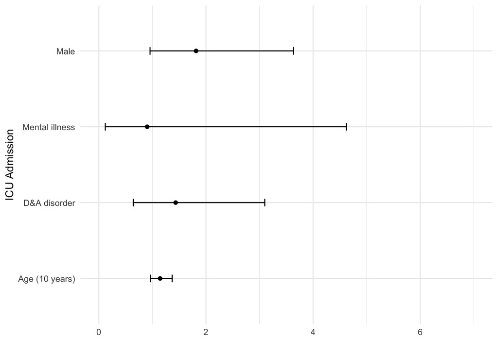

```r
risk_plot4 <- ggplot(thing, aes(x = variable, y = effect_size)) +
  geom_point() +
  geom_errorbar(aes(ymin = `2.5 %`, ymax = `97.5 %`), width = 0.1) +
  xlab('ICU Admission') +
  ylab('') +
  ylim(0,7) +
  #scale_y_continuous(breaks= 0:7) +
  scale_x_discrete(labels = c("statushomeless" = "Homeless", "age" = "Age (10 years)", "sexM" = "Male", "da_disorderTRUE" = "D&A disorder", "mental_illnessTRUE" = "Mental illness")) +
  coord_flip() +
  theme_minimal()

risk_plot4
```

### ICU Hours

To determine the effects on a patient’s length of stay in ICU, we fit linear models to our data set. Firstly, we need to make a log transform to our outcome variable to fit the model properly.

```r
homeless_data <- homeless_data %>%
  mutate(icu_hrs_trans = ifelse(icu_hrs == 0, NA, log(icu_hrs)))

icu_lm <- lm(icu_hrs_trans ~ status + age + sex + da_disorder + mental_illness,
             data = homeless_data)

icu_lm_summary <- icu_lm %>% summary
icu_lm_summary
```

```
##
## Call:
## lm(formula = icu_hrs_trans ~ status + age + sex + da_disorder +
##     mental_illness, data = homeless_data)
##
## Residuals:
##      Min       1Q   Median       3Q      Max
## -3.00306 -0.53860  0.00987  0.47742  1.79868
##
## Coefficients:
##                    Estimate Std. Error t value Pr(>|t|)
## (Intercept)         3.93270    0.59721   6.585 4.59e-09 ***
## statushomeless     -0.53287    0.43815  -1.216    0.228
## age                -0.02457    0.06699  -0.367    0.715
## sexM               -0.06942    0.25708  -0.270    0.788
## da_disorderTRUE     0.02714    0.27798   0.098    0.922
## mental_illnessTRUE  1.08627    0.75823   1.433    0.156
## ---
## Signif. codes:  0 '***' 0.001 '**' 0.01 '*' 0.05 '.' 0.1 ' ' 1
##
## Residual standard error: 0.8365 on 79 degrees of freedom
##   (200 observations deleted due to missingness)
## Multiple R-squared:  0.03216,    Adjusted R-squared:  -0.02909
## F-statistic: 0.5251 on 5 and 79 DF,  p-value: 0.7566
```

We observe that the variables `status` (P = 0.2275333) `age` (P = 0.714754) and `sex` (P = 0.7878495) didn’t contribute to the model. As such we eliminate the terms from the modelling to reach our final model.

```r
icu_lm_final <- lm(icu_hrs_trans ~ da_disorder + mental_illness,
                   data = homeless_data)

# get interesting stuff into a df
icu_lm_final %>%
  summ(confint = TRUE, digits = 3)
```

```
## MODEL INFO:
## Observations: 85 (200 missing obs. deleted)
## Dependent Variable: icu_hrs_trans
## Type: OLS linear regression
##
## MODEL FIT:
## F(2,82) = 0.524, p = 0.594
## R² = 0.013
## Adj. R² = -0.011
##
## Standard errors: OLS
## ------------------------------------------------------------------
##                             Est.     2.5%   97.5%   t val.       p
## ------------------------ ------- -------- ------- -------- -------
## (Intercept)                3.673    3.479   3.868   37.585   0.000
## da_disorderTRUE            0.024   -0.510   0.558    0.091   0.928
## mental_illnessTRUE         0.584   -0.684   1.852    0.916   0.362
## ------------------------------------------------------------------
```

```r
# transform the coefficients into risk factors
icu_lm_final %>%
  with(cbind(exp(coefficients(.)), exp(confint(.))))
```

```
##                                   2.5 %    97.5 %
## (Intercept)        39.385212 32.4260886 47.837867
## da_disorderTRUE     1.024709  0.6006977  1.748013
## mental_illnessTRUE  1.792942  0.5044284  6.372841
```

```r
# transform the coefficients into risk factors
thing <- icu_lm_final %>%
  with(cbind(exp(coefficients(.)), exp(confint(.)))) %>% as.data.frame() %>%
  mutate(variable = rownames(.)) %>%
  rename("effect_size" = "V1") %>%
  filter(variable != "(Intercept)")

thing
```

```
##                    effect_size     2.5 %   97.5 %           variable
## da_disorderTRUE       1.024709 0.6006977 1.748013    da_disorderTRUE
## mental_illnessTRUE    1.792942 0.5044284 6.372841 mental_illnessTRUE
```

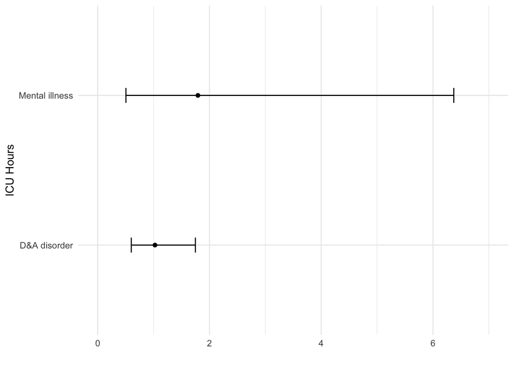

```r
risk_plot5 <- ggplot(thing, aes(x = variable, y = effect_size)) +
  geom_point() +
  geom_errorbar(aes(ymin = `2.5 %`, ymax = `97.5 %`), width = 0.1) +
  xlab('ICU Hours') +
  ylab('') +
  ylim(0,7) +
  #scale_y_continuous(breaks= 0:7) +
  scale_x_discrete(labels = c("statushomeless" = "Homeless", "age" = "Age (10 years)", "sexM" = "Male", "da_disorderTRUE" = "D&A disorder", "mental_illnessTRUE" = "Mental illness")) +
  coord_flip() +
  theme_minimal()

risk_plot5
```

### Discharge against medical advice

To determine the effects on patients risk to discharge themselves at their risk post-surgery, we fit a logistic regression model to our data set as so:

```r
daor_glm <- glm(daor ~ status + age + sex + da_disorder + mental_illness,
                family = binomial(),
                data = homeless_data)

daor_glm_summary <- daor_glm %>% summary
daor_glm_summary
```

```
##
## Call:
## glm(formula = daor ~ status + age + sex + da_disorder + mental_illness,
##     family = binomial(), data = homeless_data)
##
## Deviance Residuals:
##     Min       1Q   Median       3Q      Max
## -0.8877  -0.2249  -0.1914  -0.1669   3.3276
##
## Coefficients:
##                    Estimate Std. Error z value Pr(>|z|)
## (Intercept)        -1.95460    1.69732  -1.152  0.24949
## statushomeless      0.81808    1.51606   0.540  0.58947
## age                -0.27207    0.22336  -1.218  0.22320
## sexM                0.05846    0.93973   0.062  0.95040
## da_disorderTRUE    -1.59591    1.61476  -0.988  0.32299
## mental_illnessTRUE  3.15843    1.17887   2.679  0.00738 **
## ---
## Signif. codes:  0 '***' 0.001 '**' 0.01 '*' 0.05 '.' 0.1 ' ' 1
##
## (Dispersion parameter for binomial family taken to be 1)
##
##     Null deviance: 72.942  on 284  degrees of freedom
## Residual deviance: 63.715  on 279  degrees of freedom
## AIC: 75.715
##
## Number of Fisher Scoring iterations: 7
```

```r
daor_glm_final <- glm(daor ~ status + age + sex + da_disorder,
                      family = binomial(),
                      data = homeless_data)

# get interesting stuff into a df
daor_glm_final %>%
  summ(confint = TRUE, digits = 3)
```

```
## MODEL INFO:
## Observations: 285
## Dependent Variable: daor
## Type: Generalized linear model
##   Family: binomial
##   Link function: logit
##
## MODEL FIT:
## χ²(4) = 3.036, p = 0.552
## Pseudo-R² (Cragg-Uhler) = 0.047
## Pseudo-R² (McFadden) = 0.042
## AIC = 79.906, BIC = 98.169
##
## Standard errors: MLE
## ----------------------------------------------------------------
##                           Est.     2.5%   97.5%   z val.       p
## --------------------- -------- -------- ------- -------- -------
## (Intercept)             -1.453   -4.471   1.564   -0.944   0.345
## statushomeless           1.481   -0.896   3.859    1.221   0.222
## age                     -0.288   -0.696   0.121   -1.380   0.168
## sexM                    -0.285   -1.964   1.393   -0.333   0.739
## da_disorderTRUE         -0.592   -2.892   1.709   -0.504   0.614
## ----------------------------------------------------------------
```

```r
# transform the coefficients into risk factors
thing <- daor_glm_final %>%
  with(cbind(exp(coefficients(.)), exp(confint(.)))) %>% as.data.frame() %>%
  mutate(variable = rownames(.)) %>%
  rename("effect_size" = "V1") %>%
  filter(variable != "(Intercept)")

thing
```

```
##                 effect_size      2.5 %    97.5 %        variable
## statushomeless    4.3992891 0.20235631 37.055942  statushomeless
## age               0.7499600 0.50255937  1.159094             age
## sexM              0.7516601 0.15484722  5.388467            sexM
## da_disorderTRUE   0.5533496 0.02603622  3.875624 da_disorderTRUE
```

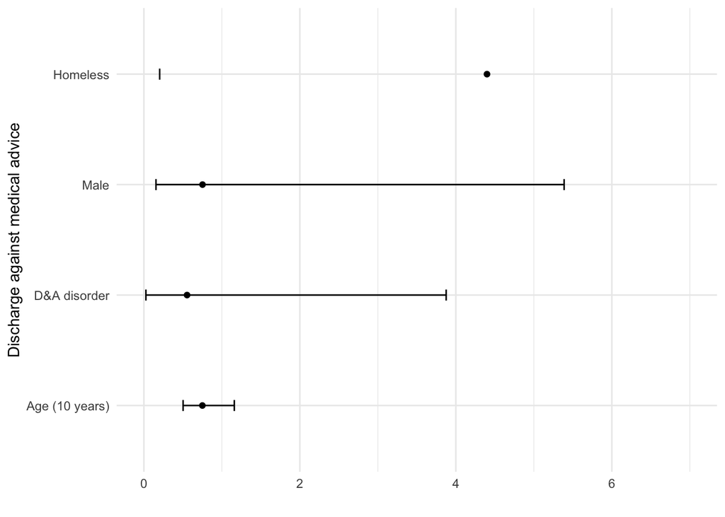

```r
risk_plot6 <- ggplot(thing, aes(x = variable, y = effect_size)) +
  geom_point() +
  geom_errorbar(aes(ymin = `2.5 %`, ymax = `97.5 %`), width = 0.1) +
  xlab('Discharge against medical advice') +
  ylab('') +
  ylim(0,7) +
  #scale_y_continuous(breaks= 0:7) +
  scale_x_discrete(labels = c("statushomeless" = "Homeless", "age" = "Age (10 years)", "sexM" = "Male", "da_disorderTRUE" = "D&A disorder", "mental_illnessTRUE" = "Mental illness")) +
  coord_flip() +
  theme_minimal()

risk_plot6
```

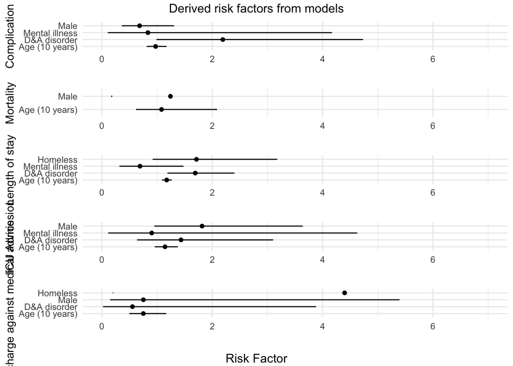

```r
# combine the graphs together
risk_plots <- ggarrange(risk_plot1, risk_plot2, risk_plot3, risk_plot4, risk_plot6,
          ncol = 1,
          widths = c(1, 1, 1, 1, 1, 1),
          common.legend = T,
          legend = "bottom")

annotate_figure(risk_plots,
                top = text_grob("Derived risk factors from models"),
                bottom = text_grob("Risk Factor"))
```